# Risk Factor Analysis

## Outcome Variable

**Outcome Variable:** swasted

## Predictor Variables

**Intervention Variable:** birthlen

**Adjustment Set:**

- arm
- sex
- W_mage
- meducyrs
- feducyrs
- vagbrth
- single
- brthmon
- W_parity
- delta_W_mage
- delta_meducyrs
- delta_feducyrs
- delta_vagbrth
- delta_single
- delta_brthmon
- delta_W_parity

## Stratifying Variables

The analysis was stratified on these variable(s):

- agecat
- studyid
- country

## Data Summary

| agecat | studyid | country | birthlen | swasted | n_cell | n |
| --- | --- | --- | --- | --- | --- | --- |
| Birth | ki0047075b-MAL-ED | BANGLADESH | >=50 cm | 0 | 25 | 241 |
| Birth | ki0047075b-MAL-ED | BANGLADESH | >=50 cm | 1 | 4 | 241 |
| Birth | ki0047075b-MAL-ED | BANGLADESH | <48 cm | 0 | 126 | 241 |
| Birth | ki0047075b-MAL-ED | BANGLADESH | <48 cm | 1 | 2 | 241 |
| Birth | ki0047075b-MAL-ED | BANGLADESH | [48-50) cm | 0 | 82 | 241 |
| Birth | ki0047075b-MAL-ED | BANGLADESH | [48-50) cm | 1 | 2 | 241 |
| Birth | ki0047075b-MAL-ED | BRAZIL | >=50 cm | 0 | 34 | 183 |
| Birth | ki0047075b-MAL-ED | BRAZIL | >=50 cm | 1 | 0 | 183 |
| Birth | ki0047075b-MAL-ED | BRAZIL | <48 cm | 0 | 73 | 183 |
| Birth | ki0047075b-MAL-ED | BRAZIL | <48 cm | 1 | 0 | 183 |
| Birth | ki0047075b-MAL-ED | BRAZIL | [48-50) cm | 0 | 76 | 183 |
| Birth | ki0047075b-MAL-ED | BRAZIL | [48-50) cm | 1 | 0 | 183 |
| Birth | ki0047075b-MAL-ED | INDIA | >=50 cm | 0 | 25 | 203 |
| Birth | ki0047075b-MAL-ED | INDIA | >=50 cm | 1 | 0 | 203 |
| Birth | ki0047075b-MAL-ED | INDIA | <48 cm | 0 | 98 | 203 |
| Birth | ki0047075b-MAL-ED | INDIA | <48 cm | 1 | 6 | 203 |
| Birth | ki0047075b-MAL-ED | INDIA | [48-50) cm | 0 | 73 | 203 |
| Birth | ki0047075b-MAL-ED | INDIA | [48-50) cm | 1 | 1 | 203 |
| Birth | ki0047075b-MAL-ED | NEPAL | >=50 cm | 0 | 36 | 168 |
| Birth | ki0047075b-MAL-ED | NEPAL | >=50 cm | 1 | 2 | 168 |
| Birth | ki0047075b-MAL-ED | NEPAL | <48 cm | 0 | 62 | 168 |
| Birth | ki0047075b-MAL-ED | NEPAL | <48 cm | 1 | 2 | 168 |
| Birth | ki0047075b-MAL-ED | NEPAL | [48-50) cm | 0 | 66 | 168 |
| Birth | ki0047075b-MAL-ED | NEPAL | [48-50) cm | 1 | 0 | 168 |
| Birth | ki0047075b-MAL-ED | PERU | >=50 cm | 0 | 34 | 279 |
| Birth | ki0047075b-MAL-ED | PERU | >=50 cm | 1 | 0 | 279 |
| Birth | ki0047075b-MAL-ED | PERU | <48 cm | 0 | 134 | 279 |
| Birth | ki0047075b-MAL-ED | PERU | <48 cm | 1 | 0 | 279 |
| Birth | ki0047075b-MAL-ED | PERU | [48-50) cm | 0 | 111 | 279 |
| Birth | ki0047075b-MAL-ED | PERU | [48-50) cm | 1 | 0 | 279 |

[output cut: 432 more lines]

The following strata were considered:

- agecat: 24 months, studyid: ki0047075b-MAL-ED, country: BANGLADESH
- agecat: 24 months, studyid: ki0047075b-MAL-ED, country: BRAZIL
- agecat: 24 months, studyid: ki0047075b-MAL-ED, country: INDIA
- agecat: 24 months, studyid: ki0047075b-MAL-ED, country: NEPAL
- agecat: 24 months, studyid: ki0047075b-MAL-ED, country: PERU
- agecat: 24 months, studyid: ki0047075b-MAL-ED, country: SOUTH AFRICA
- agecat: 24 months, studyid: ki0047075b-MAL-ED, country: TANZANIA, UNITED REPUBLIC OF
- agecat: 24 months, studyid: ki1000108-CMC-V-BCS-2002, country: INDIA
- agecat: 24 months, studyid: ki1000108-IRC, country: INDIA
- agecat: 24 months, studyid: ki1017093-NIH-Birth, country: BANGLADESH
- agecat: 24 months, studyid: ki1017093b-PROVIDE, country: BANGLADESH
- agecat: 24 months, studyid: ki1017093c-NIH-Crypto, country: BANGLADESH
- agecat: 24 months, studyid: ki1101329-Keneba, country: GAMBIA
- agecat: 24 months, studyid: ki1114097-CMIN, country: BANGLADESH
- agecat: 24 months, studyid: ki1114097-CMIN, country: PERU
- agecat: 24 months, studyid: ki1114097-CONTENT, country: PERU
- agecat: 24 months, studyid: ki1119695-PROBIT, country: BELARUS
- agecat: 24 months, studyid: ki1126311-ZVITAMBO, country: ZIMBABWE
- agecat: 24 months, studyid: ki1135781-COHORTS, country: GUATEMALA
- agecat: 24 months, studyid: ki1135781-COHORTS, country: INDIA
- agecat: 24 months, studyid: ki1135781-COHORTS, country: PHILIPPINES
- agecat: 24 months, studyid: kiGH5241-JiVitA-3, country: BANGLADESH
- agecat: 24 months, studyid: kiGH5241-JiVitA-4, country: BANGLADESH
- agecat: 6 months, studyid: ki0047075b-MAL-ED, country: BANGLADESH
- agecat: 6 months, studyid: ki0047075b-MAL-ED, country: BRAZIL
- agecat: 6 months, studyid: ki0047075b-MAL-ED, country: INDIA
- agecat: 6 months, studyid: ki0047075b-MAL-ED, country: NEPAL
- agecat: 6 months, studyid: ki0047075b-MAL-ED, country: PERU
- agecat: 6 months, studyid: ki0047075b-MAL-ED, country: SOUTH AFRICA
- agecat: 6 months, studyid: ki0047075b-MAL-ED, country: TANZANIA, UNITED REPUBLIC OF
- agecat: 6 months, studyid: ki1000108-CMC-V-BCS-2002, country: INDIA
- agecat: 6 months, studyid: ki1000108-IRC, country: INDIA
- agecat: 6 months, studyid: ki1000109-EE, country: PAKISTAN
- agecat: 6 months, studyid: ki1000109-ResPak, country: PAKISTAN
- agecat: 6 months, studyid: ki1000304b-SAS-CompFeed, country: INDIA
- agecat: 6 months, studyid: ki1017093-NIH-Birth, country: BANGLADESH
- agecat: 6 months, studyid: ki1017093b-PROVIDE, country: BANGLADESH
- agecat: 6 months, studyid: ki1017093c-NIH-Crypto, country: BANGLADESH
- agecat: 6 months, studyid: ki1101329-Keneba, country: GAMBIA
- agecat: 6 months, studyid: ki1114097-CMIN, country: BANGLADESH
- agecat: 6 months, studyid: ki1114097-CMIN, country: BRAZIL
- agecat: 6 months, studyid: ki1114097-CMIN, country: GUINEA-BISSAU
- agecat: 6 months, studyid: ki1114097-CMIN, country: PERU
- agecat: 6 months, studyid: ki1114097-CONTENT, country: PERU
- agecat: 6 months, studyid: ki1119695-PROBIT, country: BELARUS
- agecat: 6 months, studyid: ki1126311-ZVITAMBO, country: ZIMBABWE
- agecat: 6 months, studyid: ki1135781-COHORTS, country: GUATEMALA
- agecat: 6 months, studyid: ki1135781-COHORTS, country: INDIA
- agecat: 6 months, studyid: ki1135781-COHORTS, country: PHILIPPINES
- agecat: 6 months, studyid: kiGH5241-JiVitA-3, country: BANGLADESH
- agecat: 6 months, studyid: kiGH5241-JiVitA-4, country: BANGLADESH
- agecat: Birth, studyid: ki0047075b-MAL-ED, country: BANGLADESH
- agecat: Birth, studyid: ki0047075b-MAL-ED, country: BRAZIL
- agecat: Birth, studyid: ki0047075b-MAL-ED, country: INDIA
- agecat: Birth, studyid: ki0047075b-MAL-ED, country: NEPAL
- agecat: Birth, studyid: ki0047075b-MAL-ED, country: PERU
- agecat: Birth, studyid: ki0047075b-MAL-ED, country: SOUTH AFRICA
- agecat: Birth, studyid: ki0047075b-MAL-ED, country: TANZANIA, UNITED REPUBLIC OF
- agecat: Birth, studyid: ki1000108-CMC-V-BCS-2002, country: INDIA
- agecat: Birth, studyid: ki1000108-IRC, country: INDIA
- agecat: Birth, studyid: ki1000109-EE, country: PAKISTAN
- agecat: Birth, studyid: ki1000109-ResPak, country: PAKISTAN
- agecat: Birth, studyid: ki1000304b-SAS-CompFeed, country: INDIA
- agecat: Birth, studyid: ki1017093-NIH-Birth, country: BANGLADESH
- agecat: Birth, studyid: ki1017093c-NIH-Crypto, country: BANGLADESH
- agecat: Birth, studyid: ki1101329-Keneba, country: GAMBIA
- agecat: Birth, studyid: ki1114097-CMIN, country: BANGLADESH
- agecat: Birth, studyid: ki1114097-CMIN, country: BRAZIL
- agecat: Birth, studyid: ki1114097-CMIN, country: PERU
- agecat: Birth, studyid: ki1114097-CONTENT, country: PERU
- agecat: Birth, studyid: ki1119695-PROBIT, country: BELARUS
- agecat: Birth, studyid: ki1126311-ZVITAMBO, country: ZIMBABWE
- agecat: Birth, studyid: ki1135781-COHORTS, country: GUATEMALA
- agecat: Birth, studyid: ki1135781-COHORTS, country: INDIA
- agecat: Birth, studyid: ki1135781-COHORTS, country: PHILIPPINES
- agecat: Birth, studyid: kiGH5241-JiVitA-3, country: BANGLADESH
- agecat: Birth, studyid: kiGH5241-JiVitA-4, country: BANGLADESH

### Dropped Strata

Some strata were dropped due to rare outcomes:

- agecat: Birth, studyid: ki0047075b-MAL-ED, country: BANGLADESH
- agecat: Birth, studyid: ki0047075b-MAL-ED, country: BRAZIL
- agecat: Birth, studyid: ki0047075b-MAL-ED, country: INDIA
- agecat: Birth, studyid: ki0047075b-MAL-ED, country: NEPAL
- agecat: Birth, studyid: ki0047075b-MAL-ED, country: PERU
- agecat: Birth, studyid: ki0047075b-MAL-ED, country: SOUTH AFRICA
- agecat: Birth, studyid: ki0047075b-MAL-ED, country: TANZANIA, UNITED REPUBLIC OF
- agecat: Birth, studyid: ki1000108-CMC-V-BCS-2002, country: INDIA
- agecat: Birth, studyid: ki1000109-EE, country: PAKISTAN
- agecat: Birth, studyid: ki1000109-ResPak, country: PAKISTAN
- agecat: Birth, studyid: ki1000304b-SAS-CompFeed, country: INDIA
- agecat: Birth, studyid: ki1017093-NIH-Birth, country: BANGLADESH
- agecat: Birth, studyid: ki1017093c-NIH-Crypto, country: BANGLADESH
- agecat: Birth, studyid: ki1101329-Keneba, country: GAMBIA
- agecat: Birth, studyid: ki1114097-CMIN, country: BANGLADESH
- agecat: Birth, studyid: ki1114097-CMIN, country: BRAZIL
- agecat: Birth, studyid: ki1114097-CMIN, country: PERU
- agecat: Birth, studyid: ki1114097-CONTENT, country: PERU
- agecat: Birth, studyid: ki1119695-PROBIT, country: BELARUS
- agecat: Birth, studyid: ki1135781-COHORTS, country: GUATEMALA
- agecat: Birth, studyid: kiGH5241-JiVitA-4, country: BANGLADESH
- agecat: 6 months, studyid: ki0047075b-MAL-ED, country: BANGLADESH
- agecat: 6 months, studyid: ki0047075b-MAL-ED, country: BRAZIL
- agecat: 6 months, studyid: ki0047075b-MAL-ED, country: INDIA
- agecat: 6 months, studyid: ki0047075b-MAL-ED, country: NEPAL
- agecat: 6 months, studyid: ki0047075b-MAL-ED, country: PERU
- agecat: 6 months, studyid: ki0047075b-MAL-ED, country: SOUTH AFRICA
- agecat: 6 months, studyid: ki0047075b-MAL-ED, country: TANZANIA, UNITED REPUBLIC OF
- agecat: 6 months, studyid: ki1000108-CMC-V-BCS-2002, country: INDIA
- agecat: 6 months, studyid: ki1000108-IRC, country: INDIA
- agecat: 6 months, studyid: ki1000109-EE, country: PAKISTAN
- agecat: 6 months, studyid: ki1000109-ResPak, country: PAKISTAN
- agecat: 6 months, studyid: ki1000304b-SAS-CompFeed, country: INDIA
- agecat: 6 months, studyid: ki1017093-NIH-Birth, country: BANGLADESH
- agecat: 6 months, studyid: ki1017093b-PROVIDE, country: BANGLADESH
- agecat: 6 months, studyid: ki1017093c-NIH-Crypto, country: BANGLADESH
- agecat: 6 months, studyid: ki1101329-Keneba, country: GAMBIA
- agecat: 6 months, studyid: ki1114097-CMIN, country: BANGLADESH
- agecat: 6 months, studyid: ki1114097-CMIN, country: BRAZIL
- agecat: 6 months, studyid: ki1114097-CMIN, country: GUINEA-BISSAU
- agecat: 6 months, studyid: ki1114097-CMIN, country: PERU
- agecat: 6 months, studyid: ki1114097-CONTENT, country: PERU
- agecat: 6 months, studyid: ki1119695-PROBIT, country: BELARUS
- agecat: 6 months, studyid: ki1135781-COHORTS, country: GUATEMALA
- agecat: 6 months, studyid: kiGH5241-JiVitA-4, country: BANGLADESH
- agecat: 24 months, studyid: ki0047075b-MAL-ED, country: BANGLADESH
- agecat: 24 months, studyid: ki0047075b-MAL-ED, country: BRAZIL
- agecat: 24 months, studyid: ki0047075b-MAL-ED, country: INDIA
- agecat: 24 months, studyid: ki0047075b-MAL-ED, country: NEPAL
- agecat: 24 months, studyid: ki0047075b-MAL-ED, country: PERU
- agecat: 24 months, studyid: ki0047075b-MAL-ED, country: SOUTH AFRICA
- agecat: 24 months, studyid: ki0047075b-MAL-ED, country: TANZANIA, UNITED REPUBLIC OF
- agecat: 24 months, studyid: ki1000108-CMC-V-BCS-2002, country: INDIA
- agecat: 24 months, studyid: ki1000108-IRC, country: INDIA
- agecat: 24 months, studyid: ki1017093-NIH-Birth, country: BANGLADESH
- agecat: 24 months, studyid: ki1017093b-PROVIDE, country: BANGLADESH
- agecat: 24 months, studyid: ki1017093c-NIH-Crypto, country: BANGLADESH
- agecat: 24 months, studyid: ki1114097-CMIN, country: BANGLADESH
- agecat: 24 months, studyid: ki1114097-CMIN, country: PERU
- agecat: 24 months, studyid: ki1114097-CONTENT, country: PERU
- agecat: 24 months, studyid: ki1119695-PROBIT, country: BELARUS
- agecat: 24 months, studyid: ki1126311-ZVITAMBO, country: ZIMBABWE
- agecat: 24 months, studyid: ki1135781-COHORTS, country: GUATEMALA
- agecat: 24 months, studyid: ki1135781-COHORTS, country: PHILIPPINES

## Methods Detail

We’re interested in the causal parameters $E[Y_a]$ for all values of $a \in \mathcal{A}$. These parameters represent the mean outcome if, possibly contrary to fact, we intervened to set all units to have $A=a$. Under the randomization and positivity assumptions, these are identified by the statistical parameters $\psi_a=E_W[E_{Y|A,W}(Y|A=a,W)]$. In addition, we’re interested in the mean of $Y$, $E[Y]$ under no intervention (the observed mean). We will estimate these parameters by using SuperLearner to fit the relevant likelihood factors – $E_{Y|A,W}(Y|A=a,W)$ and $p(A=a|W)$, and then updating our likelihood fit using a joint TMLE.

For unadjusted analyses ($W=\{\}$), initial likelihoods were estimated using Lrnr_glm to estimate the simple $E(Y|A)$ and Lrnr_mean to estimate $p(A)$. For adjusted analyses, a small library containing Lrnr_glmnet, Lrnr_xgboost, and Lrnr_mean was used.

Having estimated these parameters, we will then use the delta method to estimate relative risks and attributable risks relative to a prespecified baseline level of $A$.

# Results Detail

## Results Plots

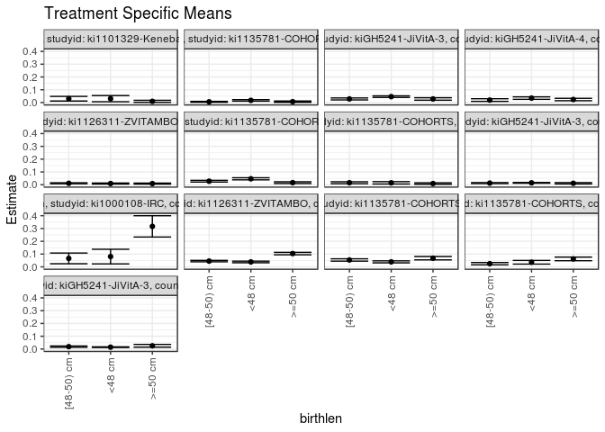

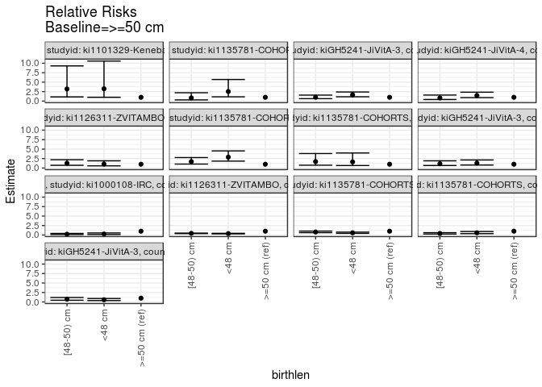

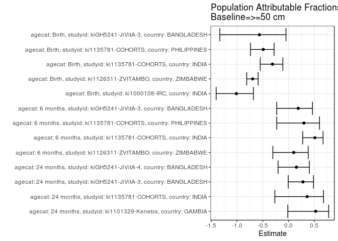

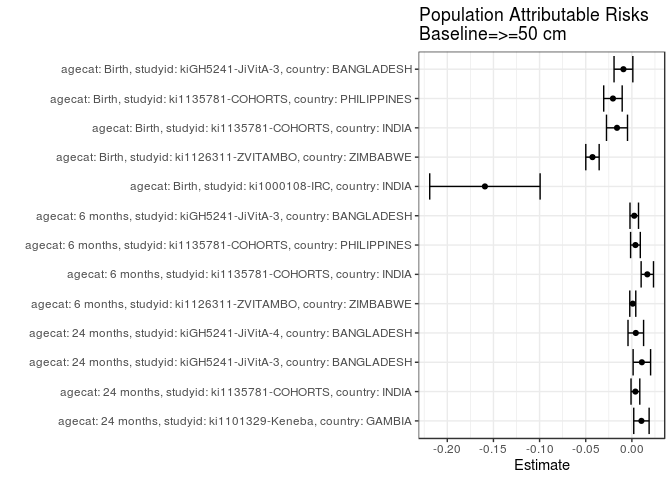

## Results Table

### Parameter: TSM

| agecat | studyid | country | intervention_level | baseline_level | estimate | ci_lower | ci_upper |
| --- | --- | --- | --- | --- | --- | --- | --- |
| Birth | ki1000108-IRC | INDIA | >=50 cm | NA | 0.3166667 | 0.2333160 | 0.4000173 |
| Birth | ki1000108-IRC | INDIA | <48 cm | NA | 0.0804598 | 0.0232201 | 0.1376995 |
| Birth | ki1000108-IRC | INDIA | [48-50) cm | NA | 0.0661765 | 0.0243360 | 0.1080170 |
| Birth | ki1126311-ZVITAMBO | ZIMBABWE | >=50 cm | NA | 0.1039342 | 0.0944185 | 0.1134498 |
| Birth | ki1126311-ZVITAMBO | ZIMBABWE | <48 cm | NA | 0.0385281 | 0.0322517 | 0.0448045 |
| Birth | ki1126311-ZVITAMBO | ZIMBABWE | [48-50) cm | NA | 0.0451168 | 0.0394854 | 0.0507481 |
| Birth | ki1135781-COHORTS | INDIA | >=50 cm | NA | 0.0677876 | 0.0544934 | 0.0810818 |
| Birth | ki1135781-COHORTS | INDIA | <48 cm | NA | 0.0390873 | 0.0312698 | 0.0469049 |
| Birth | ki1135781-COHORTS | INDIA | [48-50) cm | NA | 0.0538541 | 0.0447691 | 0.0629392 |
| Birth | ki1135781-COHORTS | PHILIPPINES | >=50 cm | NA | 0.0622516 | 0.0481156 | 0.0763876 |
| Birth | ki1135781-COHORTS | PHILIPPINES | <48 cm | NA | 0.0360088 | 0.0216285 | 0.0503891 |
| Birth | ki1135781-COHORTS | PHILIPPINES | [48-50) cm | NA | 0.0249665 | 0.0159378 | 0.0339952 |
| Birth | kiGH5241-JiVitA-3 | BANGLADESH | >=50 cm | NA | 0.0253097 | 0.0145827 | 0.0360367 |
| Birth | kiGH5241-JiVitA-3 | BANGLADESH | <48 cm | NA | 0.0145682 | 0.0120976 | 0.0170388 |
| Birth | kiGH5241-JiVitA-3 | BANGLADESH | [48-50) cm | NA | 0.0184825 | 0.0135326 | 0.0234324 |
| 6 months | ki1126311-ZVITAMBO | ZIMBABWE | >=50 cm | NA | 0.0086897 | 0.0049179 | 0.0124615 |
| 6 months | ki1126311-ZVITAMBO | ZIMBABWE | <48 cm | NA | 0.0091172 | 0.0053797 | 0.0128547 |
| 6 months | ki1126311-ZVITAMBO | ZIMBABWE | [48-50) cm | NA | 0.0110193 | 0.0073002 | 0.0147384 |
| 6 months | ki1135781-COHORTS | INDIA | >=50 cm | NA | 0.0160704 | 0.0093751 | 0.0227657 |
| 6 months | ki1135781-COHORTS | INDIA | <48 cm | NA | 0.0462692 | 0.0380652 | 0.0544731 |
| 6 months | ki1135781-COHORTS | INDIA | [48-50) cm | NA | 0.0274061 | 0.0206465 | 0.0341657 |
| 6 months | ki1135781-COHORTS | PHILIPPINES | >=50 cm | NA | 0.0091001 | 0.0031808 | 0.0150194 |
| 6 months | ki1135781-COHORTS | PHILIPPINES | <48 cm | NA | 0.0147710 | 0.0056822 | 0.0238599 |
| 6 months | ki1135781-COHORTS | PHILIPPINES | [48-50) cm | NA | 0.0154889 | 0.0079571 | 0.0230207 |
| 6 months | kiGH5241-JiVitA-3 | BANGLADESH | >=50 cm | NA | 0.0111387 | 0.0061288 | 0.0161485 |
| 6 months | kiGH5241-JiVitA-3 | BANGLADESH | <48 cm | NA | 0.0145773 | 0.0118194 | 0.0173351 |
| 6 months | kiGH5241-JiVitA-3 | BANGLADESH | [48-50) cm | NA | 0.0126017 | 0.0087304 | 0.0164729 |
| 24 months | ki1101329-Keneba | GAMBIA | >=50 cm | NA | 0.0093458 | 0.0011885 | 0.0175031 |
| 24 months | ki1101329-Keneba | GAMBIA | <48 cm | NA | 0.0304569 | 0.0064495 | 0.0544642 |
| 24 months | ki1101329-Keneba | GAMBIA | [48-50) cm | NA | 0.0299401 | 0.0116547 | 0.0482255 |
| 24 months | ki1135781-COHORTS | INDIA | >=50 cm | NA | 0.0067633 | 0.0017695 | 0.0117571 |
| 24 months | ki1135781-COHORTS | INDIA | <48 cm | NA | 0.0171162 | 0.0113260 | 0.0229064 |
| 24 months | ki1135781-COHORTS | INDIA | [48-50) cm | NA | 0.0056850 | 0.0021711 | 0.0091990 |
| 24 months | kiGH5241-JiVitA-3 | BANGLADESH | >=50 cm | NA | 0.0279247 | 0.0182495 | 0.0375999 |
| 24 months | kiGH5241-JiVitA-3 | BANGLADESH | <48 cm | NA | 0.0461760 | 0.0400054 | 0.0523466 |
| 24 months | kiGH5241-JiVitA-3 | BANGLADESH | [48-50) cm | NA | 0.0282003 | 0.0204585 | 0.0359421 |
| 24 months | kiGH5241-JiVitA-4 | BANGLADESH | >=50 cm | NA | 0.0236839 | 0.0144110 | 0.0329568 |
| 24 months | kiGH5241-JiVitA-4 | BANGLADESH | <48 cm | NA | 0.0346430 | 0.0249904 | 0.0442956 |
| 24 months | kiGH5241-JiVitA-4 | BANGLADESH | [48-50) cm | NA | 0.0194565 | 0.0091616 | 0.0297514 |

### Parameter: E(Y)

| agecat | studyid | country | intervention_level | baseline_level | estimate | ci_lower | ci_upper |
| --- | --- | --- | --- | --- | --- | --- | --- |
| Birth | ki1000108-IRC | INDIA | NA | NA | 0.1574344 | 0.1188345 | 0.1960344 |
| Birth | ki1126311-ZVITAMBO | ZIMBABWE | NA | NA | 0.0612419 | 0.0571066 | 0.0653771 |
| Birth | ki1135781-COHORTS | INDIA | NA | NA | 0.0516712 | 0.0461576 | 0.0571849 |
| Birth | ki1135781-COHORTS | PHILIPPINES | NA | NA | 0.0417385 | 0.0344572 | 0.0490198 |
| Birth | kiGH5241-JiVitA-3 | BANGLADESH | NA | NA | 0.0161691 | 0.0138058 | 0.0185324 |
| 6 months | ki1126311-ZVITAMBO | ZIMBABWE | NA | NA | 0.0096636 | 0.0075428 | 0.0117844 |
| 6 months | ki1135781-COHORTS | INDIA | NA | NA | 0.0328056 | 0.0283450 | 0.0372662 |
| 6 months | ki1135781-COHORTS | PHILIPPINES | NA | NA | 0.0129678 | 0.0086988 | 0.0172368 |
| 6 months | kiGH5241-JiVitA-3 | BANGLADESH | NA | NA | 0.0137136 | 0.0115856 | 0.0158416 |
| 24 months | ki1101329-Keneba | GAMBIA | NA | NA | 0.0196998 | 0.0113537 | 0.0280459 |
| 24 months | ki1135781-COHORTS | INDIA | NA | NA | 0.0105887 | 0.0076690 | 0.0135085 |
| 24 months | kiGH5241-JiVitA-3 | BANGLADESH | NA | NA | 0.0387403 | 0.0343586 | 0.0431221 |
| 24 months | kiGH5241-JiVitA-4 | BANGLADESH | NA | NA | 0.0279316 | 0.0220494 | 0.0338137 |

### Parameter: RR

| agecat | studyid | country | intervention_level | baseline_level | estimate | ci_lower | ci_upper |
| --- | --- | --- | --- | --- | --- | --- | --- |
| Birth | ki1000108-IRC | INDIA | >=50 cm | >=50 cm | 1.0000000 | 1.0000000 | 1.0000000 |
| Birth | ki1000108-IRC | INDIA | <48 cm | >=50 cm | 0.2540835 | 0.1190000 | 0.5425075 |
| Birth | ki1000108-IRC | INDIA | [48-50) cm | >=50 cm | 0.2089783 | 0.1053590 | 0.4145060 |
| Birth | ki1126311-ZVITAMBO | ZIMBABWE | >=50 cm | >=50 cm | 1.0000000 | 1.0000000 | 1.0000000 |
| Birth | ki1126311-ZVITAMBO | ZIMBABWE | <48 cm | >=50 cm | 0.3706974 | 0.3075084 | 0.4468709 |
| Birth | ki1126311-ZVITAMBO | ZIMBABWE | [48-50) cm | >=50 cm | 0.4340899 | 0.3718529 | 0.5067435 |
| Birth | ki1135781-COHORTS | INDIA | >=50 cm | >=50 cm | 1.0000000 | 1.0000000 | 1.0000000 |
| Birth | ki1135781-COHORTS | INDIA | <48 cm | >=50 cm | 0.5766143 | 0.4357886 | 0.7629481 |
| Birth | ki1135781-COHORTS | INDIA | [48-50) cm | >=50 cm | 0.7944535 | 0.6133753 | 1.0289888 |
| Birth | ki1135781-COHORTS | PHILIPPINES | >=50 cm | >=50 cm | 1.0000000 | 1.0000000 | 1.0000000 |
| Birth | ki1135781-COHORTS | PHILIPPINES | <48 cm | >=50 cm | 0.5784402 | 0.3654781 | 0.9154941 |
| Birth | ki1135781-COHORTS | PHILIPPINES | [48-50) cm | >=50 cm | 0.4010578 | 0.2616846 | 0.6146613 |
| Birth | kiGH5241-JiVitA-3 | BANGLADESH | >=50 cm | >=50 cm | 1.0000000 | 1.0000000 | 1.0000000 |
| Birth | kiGH5241-JiVitA-3 | BANGLADESH | <48 cm | >=50 cm | 0.5755980 | 0.3656540 | 0.9060834 |
| Birth | kiGH5241-JiVitA-3 | BANGLADESH | [48-50) cm | >=50 cm | 0.7302535 | 0.4522213 | 1.1792241 |
| 6 months | ki1126311-ZVITAMBO | ZIMBABWE | >=50 cm | >=50 cm | 1.0000000 | 1.0000000 | 1.0000000 |
| 6 months | ki1126311-ZVITAMBO | ZIMBABWE | <48 cm | >=50 cm | 1.0491955 | 0.5775343 | 1.9060535 |
| 6 months | ki1126311-ZVITAMBO | ZIMBABWE | [48-50) cm | >=50 cm | 1.2680876 | 0.7317240 | 2.1976131 |
| 6 months | ki1135781-COHORTS | INDIA | >=50 cm | >=50 cm | 1.0000000 | 1.0000000 | 1.0000000 |
| 6 months | ki1135781-COHORTS | INDIA | <48 cm | >=50 cm | 2.8791527 | 1.8307295 | 4.5279876 |
| 6 months | ki1135781-COHORTS | INDIA | [48-50) cm | >=50 cm | 1.7053771 | 1.0507786 | 2.7677676 |
| 6 months | ki1135781-COHORTS | PHILIPPINES | >=50 cm | >=50 cm | 1.0000000 | 1.0000000 | 1.0000000 |
| 6 months | ki1135781-COHORTS | PHILIPPINES | <48 cm | >=50 cm | 1.6231741 | 0.6629864 | 3.9739795 |
| 6 months | ki1135781-COHORTS | PHILIPPINES | [48-50) cm | >=50 cm | 1.7020544 | 0.7555587 | 3.8342347 |
| 6 months | kiGH5241-JiVitA-3 | BANGLADESH | >=50 cm | >=50 cm | 1.0000000 | 1.0000000 | 1.0000000 |
| 6 months | kiGH5241-JiVitA-3 | BANGLADESH | <48 cm | >=50 cm | 1.3087099 | 0.8020044 | 2.1355516 |
| 6 months | kiGH5241-JiVitA-3 | BANGLADESH | [48-50) cm | >=50 cm | 1.1313462 | 0.6717211 | 1.9054698 |
| 24 months | ki1101329-Keneba | GAMBIA | >=50 cm | >=50 cm | 1.0000000 | 1.0000000 | 1.0000000 |
| 24 months | ki1101329-Keneba | GAMBIA | <48 cm | >=50 cm | 3.2588832 | 1.0053237 | 10.5640797 |
| 24 months | ki1101329-Keneba | GAMBIA | [48-50) cm | >=50 cm | 3.2035928 | 1.1040590 | 9.2957052 |
| 24 months | ki1135781-COHORTS | INDIA | >=50 cm | >=50 cm | 1.0000000 | 1.0000000 | 1.0000000 |
| 24 months | ki1135781-COHORTS | INDIA | <48 cm | >=50 cm | 2.5307499 | 1.1233819 | 5.7012625 |
| 24 months | ki1135781-COHORTS | INDIA | [48-50) cm | >=50 cm | 0.8405750 | 0.3209098 | 2.2017599 |
| 24 months | kiGH5241-JiVitA-3 | BANGLADESH | >=50 cm | >=50 cm | 1.0000000 | 1.0000000 | 1.0000000 |
| 24 months | kiGH5241-JiVitA-3 | BANGLADESH | <48 cm | >=50 cm | 1.6535897 | 1.1374770 | 2.4038806 |
| 24 months | kiGH5241-JiVitA-3 | BANGLADESH | [48-50) cm | >=50 cm | 1.0098693 | 0.6457412 | 1.5793262 |
| 24 months | kiGH5241-JiVitA-4 | BANGLADESH | >=50 cm | >=50 cm | 1.0000000 | 1.0000000 | 1.0000000 |
| 24 months | kiGH5241-JiVitA-4 | BANGLADESH | <48 cm | >=50 cm | 1.4627232 | 0.9115774 | 2.3470956 |
| 24 months | kiGH5241-JiVitA-4 | BANGLADESH | [48-50) cm | >=50 cm | 0.8215080 | 0.4239634 | 1.5918244 |

### Parameter: PAR

| agecat | studyid | country | intervention_level | baseline_level | estimate | ci_lower | ci_upper |
| --- | --- | --- | --- | --- | --- | --- | --- |
| Birth | ki1000108-IRC | INDIA | >=50 cm | NA | -0.1592323 | -0.2190334 | -0.0994311 |
| Birth | ki1126311-ZVITAMBO | ZIMBABWE | >=50 cm | NA | -0.0426923 | -0.0499391 | -0.0354456 |
| Birth | ki1135781-COHORTS | INDIA | >=50 cm | NA | -0.0161164 | -0.0275007 | -0.0047321 |
| Birth | ki1135781-COHORTS | PHILIPPINES | >=50 cm | NA | -0.0205130 | -0.0305251 | -0.0105010 |
| Birth | kiGH5241-JiVitA-3 | BANGLADESH | >=50 cm | NA | -0.0091406 | -0.0193162 | 0.0010350 |
| 6 months | ki1126311-ZVITAMBO | ZIMBABWE | >=50 cm | NA | 0.0009739 | -0.0022692 | 0.0042170 |
| 6 months | ki1135781-COHORTS | INDIA | >=50 cm | NA | 0.0167352 | 0.0100355 | 0.0234349 |
| 6 months | ki1135781-COHORTS | PHILIPPINES | >=50 cm | NA | 0.0038677 | -0.0013844 | 0.0091197 |
| 6 months | kiGH5241-JiVitA-3 | BANGLADESH | >=50 cm | NA | 0.0025749 | -0.0020411 | 0.0071910 |
| 24 months | ki1101329-Keneba | GAMBIA | >=50 cm | NA | 0.0103540 | 0.0020229 | 0.0186852 |
| 24 months | ki1135781-COHORTS | INDIA | >=50 cm | NA | 0.0038254 | -0.0009212 | 0.0085721 |
| 24 months | kiGH5241-JiVitA-3 | BANGLADESH | >=50 cm | NA | 0.0108156 | 0.0013450 | 0.0202863 |
| 24 months | kiGH5241-JiVitA-4 | BANGLADESH | >=50 cm | NA | 0.0042477 | -0.0041932 | 0.0126885 |

### Parameter: PAF

| agecat | studyid | country | intervention_level | baseline_level | estimate | ci_lower | ci_upper |
| --- | --- | --- | --- | --- | --- | --- | --- |
| Birth | ki1000108-IRC | INDIA | >=50 cm | NA | -1.0114198 | -1.4046724 | -0.6824784 |
| Birth | ki1126311-ZVITAMBO | ZIMBABWE | >=50 cm | NA | -0.6971099 | -0.8118497 | -0.5896363 |
| Birth | ki1135781-COHORTS | INDIA | >=50 cm | NA | -0.3119022 | -0.5495226 | -0.1107210 |
| Birth | ki1135781-COHORTS | PHILIPPINES | >=50 cm | NA | -0.4914654 | -0.7372283 | -0.2804702 |
| Birth | kiGH5241-JiVitA-3 | BANGLADESH | >=50 cm | NA | -0.5653149 | -1.3327929 | -0.0503336 |
| 6 months | ki1126311-ZVITAMBO | ZIMBABWE | >=50 cm | NA | 0.1007818 | -0.3052306 | 0.3804977 |
| 6 months | ki1135781-COHORTS | INDIA | >=50 cm | NA | 0.5101325 | 0.2743141 | 0.6693195 |
| 6 months | ki1135781-COHORTS | PHILIPPINES | >=50 cm | NA | 0.2982522 | -0.2288368 | 0.5992552 |
| 6 months | kiGH5241-JiVitA-3 | BANGLADESH | >=50 cm | NA | 0.1877649 | -0.2295604 | 0.4634457 |
| 24 months | ki1101329-Keneba | GAMBIA | >=50 cm | NA | 0.5255897 | -0.0150497 | 0.7782718 |
| 24 months | ki1135781-COHORTS | INDIA | >=50 cm | NA | 0.3612754 | -0.2664726 | 0.6778697 |
| 24 months | kiGH5241-JiVitA-3 | BANGLADESH | >=50 cm | NA | 0.2791829 | -0.0065220 | 0.4837894 |
| 24 months | kiGH5241-JiVitA-4 | BANGLADESH | >=50 cm | NA | 0.1520738 | -0.2042250 | 0.4029530 |